# Introduction

Tunisair serves 54 destinations in scheduled flights between Africa, Europe and the Middle East.  
The bulk of Tunisair's business is concentrated in Europe, particularly in France, with 9 routes (Paris Orly, Marseille, Nantes, etc.) compared with 5 in Italy and Germany (respectively Rome, Milan Venice and Frankfurt, Hamburg, Berlin). ..).  
The rest of the 32 European destinations are spread over the rest of the mainland countries such as Switzerland, London, Belgium, etc.  
Although belonging to the African continent, Tunisair serves only 14 African destinations for the majority concentrated on the north and west of Africa (Algiers, Casa, Tripoli, Benghazi, Oran, Dakar, Bamako, etc.).  
This choice was justified by socio-economic factors relating to the rest of the continent (low income, lack of appropriate infrastructure, political instability, etc.).  
However, the situation has changed and the indicators of the various components of the environment are improving, albeit slowly, but still continuing.  
Note in this regard, that in its 2012 recovery plan, the company plans the closure of unprofitable lines and the development of a set of services on the African continent benefiting from the growth of passenger and cargo traffic on the latter  
Like any company, Tunisair airline has in its assets, some that can be translated into competitive advantages but also handicaps that could negatively affect its development prospects in general and the African continent in particular.  
An internal diagnosis is able to list those elements that, faced with opportunities and threats, make it possible to set up more effective strategic actions.

# First step : Business understandings

Business Objectives :

> Suggest improvements, Tunisair could make to their fleet in order to attain the international standard profile.  
> Help Tunisair to be among the best airlines in Africa

Data Science Goals :

> Categorize aircrafts models  
> Determine the international standard profile of aircrafts  
> Study Tunisair's fleet and international airlines fleets 's characteristics

# Second step : Data understandings

# 1-data collection :

Scraping from

> https://www.seatguru.com/charts/shorthaul_economy.php  
> https://www.planespotters.net (recent updates jan 2018)

CSV files from

> delta.csv  
> https://www.kaggle.com/traceyvanp/airlinefleet/data

```python
import pandas as pd
from bs4 import BeautifulSoup

fname = r"C:\Users\Sedki\Desktop\Etude de la flotte Tunisair\BangkokAirways.html"
HtmlFile = open(fname, 'r', encoding='utf-8')
source_code = HtmlFile.read()
from bs4 import BeautifulSoup
soup = BeautifulSoup(source_code, 'html.parser')

table = soup.find('tbody')
rows = table.find_all('tr')

Airline = []
AircraftWithSeatmap = []
SeatPitch = []
SeatWidth = []
VideoType = []
LaptopPower = []
PowerType = []
WiFi = []
SeatType = []
rows
for tr in rows:
    cols = tr.find_all('td')

    AircraftWithSeatmap.append(cols[1].text.strip())
    SeatPitch.append(cols[2].text.strip())
    SeatWidth.append(cols[3].text.strip())
    VideoType.append(cols[4].text.strip())


    WiFi.append(cols[7].text.strip())



PremiumEconomyClass = pd.DataFrame(data={'Reg':AircraftWithSeatmap,
                        'AircraftType':SeatPitch,'config':SeatWidth,'delivered':VideoType,
                        'Age':WiFi
                         })

PremiumEconomyClass=PremiumEconomyClass[['Reg', 'AircraftType', 'config','delivered',
                                        'Age']]

PremiumEconomyClass.head(10)
```

|  | Reg | AircraftType | config | delivered | Age |
| --- | --- | --- | --- | --- | --- |
| 0 | HS-PGN | Airbus A319-132 | Y144 | 23. Jan 2009 | 9.1 Years |
| 1 | HS-PGT | Airbus A319-132 | Y144 | 05. Mar 2008 | 10.0 Years |
| 2 | HS-PGX | Airbus A319-132 | Y144 | 10. Mar 2008 | 10.0 Years |
| 3 | HS-PGY | Airbus A319-132 | Y144 | 07. Apr 2008 | 9.9 Years |
| 4 | HS-PGZ | Airbus A319-132 | Y144 | 13. Nov 2008 | 9.3 Years |
| 5 | HS-PPA | Airbus A319-132 | Y144 | 22. May 2009 | 8.8 Years |
| 6 | HS-PPB | Airbus A319-132 |  | 30. Nov 2011 | 12.2 Years |
| 7 | HS-PPC | Airbus A319-132 | Y144 | 09. Mar 2012 | 12.1 Years |
| 8 | HS-PPF | Airbus A319-131 |  | 11. May 2013 | 12.2 Years |
| 9 | HS-PPG | Airbus A319-131 |  | 21. May 2013 | 12.2 Years |

```python
PremiumEconomyClass.to_csv('C:\\Users\Sedki\Desktop\Etude de la flotte Tunisair\data\BangkokAirways.csv',index=None)
```

# BangkokAirways

```python
Bangkok=pd.read_csv('C:\\Users\Sedki\Desktop\Etude de la flotte Tunisair\data\BangkokAirways.csv')
lst = ["BangkokAirways"] * len(data['Reg'])
Bangkok['Airline']=lst
Bangkok.head()
```

|  | Reg | AircraftType | config | delivered | Age | Airline |
| --- | --- | --- | --- | --- | --- | --- |
| 0 | HS-PGN | Airbus A319-132 | Y144 | 23. Jan 2009 | 9.1 Years | BangkokAirways |
| 1 | HS-PGT | Airbus A319-132 | Y144 | 05. Mar 2008 | 10.0 Years | BangkokAirways |
| 2 | HS-PGX | Airbus A319-132 | Y144 | 10. Mar 2008 | 10.0 Years | BangkokAirways |
| 3 | HS-PGY | Airbus A319-132 | Y144 | 07. Apr 2008 | 9.9 Years | BangkokAirways |
| 4 | HS-PGZ | Airbus A319-132 | Y144 | 13. Nov 2008 | 9.3 Years | BangkokAirways |

# AegeanAirlinesGrece

```python
AegeanAirlinesGrece=pd.read_csv('C:\\Users\Sedki\Desktop\Etude de la flotte Tunisair\data\AegeanAirlinesGrece.csv')
lst = ["AegeanAirlinesGrece"] * len(AegeanAirlinesGrece['Reg'])
AegeanAirlinesGrece['Airline']=lst
AegeanAirlinesGrece.head()
```

|  | Reg | AircraftType | config | delivered | Age | Airline |
| --- | --- | --- | --- | --- | --- | --- |
| 0 | SX-DGF | Airbus A319-132 | CY138 | 27. Apr 2011 | 12.8 Years | AegeanAirlinesGrece |
| 1 | SX-DGB | Airbus A320-232 | CY168 | 19. Jan 2010 | 8.2 Years | AegeanAirlinesGrece |
| 2 | SX-DGC | Airbus A320-232 | CY168 | 06. May 2011(17. Mar 2011) | 8.3 Years | AegeanAirlinesGrece |
| 3 | SX-DGD | Airbus A320-232 | CY168 | 06. May 2011(22. Mar 2011) | 8.3 Years | AegeanAirlinesGrece |
| 4 | SX-DGE | Airbus A320-232 | CY168 | 06. May 2011(Apr 2011) | 8.5 Years | AegeanAirlinesGrece |

# AerolineasArgentinas

```python
AerolineasArgentinas=pd.read_csv('C:\\Users\Sedki\Desktop\Etude de la flotte Tunisair\data\Aerolineas Argentinas.csv')
lst = ["AerolineasArgentinas"] * len(AerolineasArgentinas['Reg'])
AerolineasArgentinas['Airline']=lst
AerolineasArgentinas.head()
```

|  | Reg | AircraftType | config | delivered | Age | Airline |
| --- | --- | --- | --- | --- | --- | --- |
| 0 | LV-FNI | Airbus A330-223 | C24Y248 | 03. Sep 2013 | 18.6 Years | AerolineasArgentinas |
| 1 | LV-FNJ | Airbus A330-223 | C24Y248 | 07. Jun 2014 | 18.3 Years | AerolineasArgentinas |
| 2 | LV-FNK | Airbus A330-223 | C24Y248 | 25. Nov 2013 | 17.4 Years | AerolineasArgentinas |
| 3 | LV-FNL | Airbus A330-223 | C24Y248 | 20. Dec 2013 | 17.3 Years | AerolineasArgentinas |
| 4 | LV-FVH | Airbus A330-202 | C24Y248 | 27. Feb 2015 | 3.0 Years | AerolineasArgentinas |

# Algerie

```python
Algerie=pd.read_csv('C:\\Users\Sedki\Desktop\Etude de la flotte Tunisair\data\AirAlgerie.csv')
lst = ["AirAlgerie"] * len(Algerie['Reg'])
Algerie['Airline']=lst
Algerie.head()
```

|  | Reg | AircraftType | config | delivered | Age | Airline |
| --- | --- | --- | --- | --- | --- | --- |
| 0 | 7T-VJA | Airbus A330-200 | C18W14Y219 | Mar 2015 | 2.9 Years | AirAlgerie |
| 1 | 7T-VJB | Airbus A330-200 | C18W14Y219 | May 2015 | 2.8 Years | AirAlgerie |
| 2 | 7T-VJC | Airbus A330-200 | C18W14Y219 | Jun 2015 | 2.7 Years | AirAlgerie |
| 3 | 7T-VJV | Airbus A330-200 | F12C40Y211 | Jan 2005 | 13.2 Years | AirAlgerie |
| 4 | 7T-VJW | Airbus A330-200 | F12C40Y211 | Feb 2005 | 13.1 Years | AirAlgerie |

# AirFrance

```python
AirFrance=pd.read_csv('C:\\Users\Sedki\Desktop\Etude de la flotte Tunisair\data\AirFrance.csv')
lst = ["AirFrance"] * len(AirFrance['Reg'])
AirFrance['Airline']=lst
AirFrance.head()
```

|  | Reg | AircraftType | config | delivered | Age | Airline |
| --- | --- | --- | --- | --- | --- | --- |
| 0 | F-GUGA | Airbus A318-111 | CY131 | 09. Oct 2003 | 14.4 Years | AirFrance |
| 1 | F-GUGB | Airbus A318-111 | CY131 | 07. Nov 2003 | 14.3 Years | AirFrance |
| 2 | F-GUGC | Airbus A318-111 | CY131 | 21. Nov 2003 | 14.3 Years | AirFrance |
| 3 | F-GUGD | Airbus A318-111 | CY131 | 05. Dec 2003 | 14.3 Years | AirFrance |
| 4 | F-GUGE | Airbus A318-111 | CY131 | 17. Dec 2003 | 14.2 Years | AirFrance |

# AirEuropaSpain

```python
AirEuropaSpain=pd.read_csv('C:\\Users\Sedki\Desktop\Etude de la flotte Tunisair\data\AirEuropaSpain.csv')
lst = ["AirEuropaSpain"] * len(AirEuropaSpain['Reg'])
AirEuropaSpain['Airline']=lst
AirEuropaSpain.head()
```

|  | Reg | AircraftType | config | delivered | Age | Airline |
| --- | --- | --- | --- | --- | --- | --- |
| 0 | EC-JPF | Airbus A330-202 | C24Y275 | 31. Mar 2006 | 11.9 Years | AirEuropaSpain |
| 1 | EC-JQG | Airbus A330-202 | C24Y275 | 24. Apr 2006 | 11.9 Years | AirEuropaSpain |
| 2 | EC-JQQ | Airbus A330-202 | C24Y275 | 18. May 2006 | 11.8 Years | AirEuropaSpain |
| 3 | EC-JZL | Airbus A330-202 | C24Y275 | 22. Feb 2007 | 11.0 Years | AirEuropaSpain |
| 4 | EC-KOM | Airbus A330-202 | C24Y275 | 30. Mar 2013(18. Jun 2008) | 9.8 Years | AirEuropaSpain |

# Alitalia

```python
Alitalia=pd.read_csv('C:\\Users\Sedki\Desktop\Etude de la flotte Tunisair\data\Alitalia.csv')

lst = ["Alitalia"] * len(Alitalia['Reg'])
Alitalia['Airline']=lst
Alitalia.head()
```

|  | Reg | AircraftType | config | delivered | Age | Airline |
| --- | --- | --- | --- | --- | --- | --- |
| 0 | EI-IMB | Airbus A319-112 | CY138 | 22. Nov 2010(23. Sep 2003) | 14.5 Years | Alitalia |
| 1 | EI-IMC | Airbus A319-112 | CY138 | 15. Nov 2010(29. Oct 2003) | 14.4 Years | Alitalia |
| 2 | EI-IMD | Airbus A319-112 | CY138 | 12. Nov 2010(28. Nov 2003) | 14.3 Years | Alitalia |
| 3 | EI-IME | Airbus A319-112 | CY138 | 10. Nov 2010(27. Jun 2002) | 15.8 Years | Alitalia |
| 4 | EI-IMF | Airbus A319-112 | CY138 | 07. Nov 2010(28. Nov 2003) | 14.3 Years | Alitalia |

# AirCôtIvoire

```python
AirCôtIvoire=pd.read_csv('C:\\Users\Sedki\Desktop\Etude de la flotte Tunisair\data\AirCôtIvoire.csv')

lst = ["AirCôtIvoire"] * len(AirCôtIvoire['Reg'])
AirCôtIvoire['Airline']=lst
AirCôtIvoire.head()
```

|  | Reg | AircraftType | config | delivered | Age | Airline |
| --- | --- | --- | --- | --- | --- | --- |
| 0 | TU-TRC | Airbus A319-112 | C16Y102 | 23. Jun 2017 | 14.1 Years | AirCôtIvoire |
| 1 | TU-TSA | Airbus A319-111 | C12Y96 | 06. Oct 2012 | 13.8 Years | AirCôtIvoire |
| 2 | TU-TSB | Airbus A319-111 | C12Y96 | 22. Oct 2012 | 13.7 Years | AirCôtIvoire |
| 3 | TU-TST | Airbus A319-112 | C12Y108 | 25. Feb 2016 | 14.3 Years | AirCôtIvoire |
| 4 | TU-TSV | Airbus A320-214(WL) | C16Y132 | 14. Jul 2017 | 0.6 Years | AirCôtIvoire |

# AngolaAirlines

```python
AngolaAirlines=pd.read_csv('C:\\Users\Sedki\Desktop\Etude de la flotte Tunisair\data\AngolaAirlines.csv')

lst = ["AngolaAirlines"] * len(AngolaAirlines['Reg'])
AngolaAirlines['Airline']=lst
AngolaAirlines.head()
```

|  | Reg | AircraftType | config | delivered | Age | Airline |
| --- | --- | --- | --- | --- | --- | --- |
| 0 | D2-TBF | Boeing 737-7M2(WL) | C12Y108 | 31. Aug 2006 | 11.6 Years | AngolaAirlines |
| 1 | D2-TBG | Boeing 737-7M2(WL) | C12Y108 | 12. Sep 2006 | 11.5 Years | AngolaAirlines |
| 2 | D2-TBH | Boeing 737-7M2(WL) | C12Y108 | 14. Sep 2006 | 11.5 Years | AngolaAirlines |
| 3 | D2-TBJ | Boeing 737-7M2(WL) | C12Y108 | 18. Jan 2007 | 11.2 Years | AngolaAirlines |
| 4 | D2-TBK | Boeing 737-7HB(QC) | NaN | Dec 2011 | 10.0 Years | AngolaAirlines |

# CondorGermany

```python
CondorGermany=pd.read_csv('C:\\Users\Sedki\Desktop\Etude de la flotte Tunisair\data\CondorGermany.csv')

lst = ["CondorGermany"] * len(CondorGermany['Reg'])
CondorGermany['Airline']=lst
CondorGermany.head()
```

|  | Reg | AircraftType | config | delivered | Age | Airline |
| --- | --- | --- | --- | --- | --- | --- |
| 0 | D-AICA | Airbus A320-212 | Y180 | 28. May 2004 | 20.1 Years | CondorGermany |
| 1 | D-AICC | Airbus A320-212 | Y180 | 28. May 2004 | 19.9 Years | CondorGermany |
| 2 | D-AICD | Airbus A320-212 | Y180 | 28. May 2004 | 19.5 Years | CondorGermany |
| 3 | D-AICE | Airbus A320-212 | Y180 | 28. May 2004 | 19.4 Years | CondorGermany |
| 4 | D-AICF | Airbus A320-212 | Y180 | 28. May 2004 | 19.4 Years | CondorGermany |

# EgyptAir

```python
EgyptAir=pd.read_csv('C:\\Users\Sedki\Desktop\Etude de la flotte Tunisair\data\EgyptAir.csv')


lst = ["EgyptAir"] * len(EgyptAir['Reg'])
EgyptAir['Airline']=lst
EgyptAir.head()
```

|  | Reg | AircraftType | config | delivered | Age | Airline |
| --- | --- | --- | --- | --- | --- | --- |
| 0 | SU-GBZ | Airbus A320-200 | C16Y129 | Oct 2003 | 14.6 Years | EgyptAir |
| 1 | SU-GCA | Airbus A320-200 | C16Y129 | Oct 2003 | 14.6 Years | EgyptAir |
| 2 | SU-GCB | Airbus A320-200 | C16Y129 | Oct 2003 | 14.6 Years | EgyptAir |
| 3 | SU-GCD | Airbus A320-200 | C16Y123 | Nov 2003 | 14.5 Years | EgyptAir |
| 4 | SU-GBT | Airbus A321-200 | C22Y139 | May 1997 | 20.8 Years | EgyptAir |

# EthiopianAirlines

```python
EthiopianAirlines=pd.read_csv('C:\\Users\Sedki\Desktop\Etude de la flotte Tunisair\data\EthiopianAirlines.csv')


lst = ["EthiopianAirlines"] * len(EthiopianAirlines['Reg'])
EthiopianAirlines['Airline']=lst
EthiopianAirlines.head()
```

|  | Reg | AircraftType | config | delivered | Age | Airline |
| --- | --- | --- | --- | --- | --- | --- |
| 0 | ET-ATQ | Airbus A350-900 | C30Y318 | Jun 2016 | 1.7 Years | EthiopianAirlines |
| 1 | ET-ATR | Airbus A350-900 | C30Y318 | Aug 2016 | 1.5 Years | EthiopianAirlines |
| 2 | ET-ATY | Airbus A350-900 | C30Y318 | Jan 2017 | 1.1 Years | EthiopianAirlines |
| 3 | ET-AUA | Airbus A350-900 | C30Y318 | Apr 2017 | 0.8 Years | EthiopianAirlines |
| 4 | ET-AUB | Airbus A350-900 | C30Y318 | Jun 2017 | 0.7 Years | EthiopianAirlines |

# EurowingsGermany

```python
EurowingsGermany=pd.read_csv('C:\\Users\Sedki\Desktop\Etude de la flotte Tunisair\data\EurowingsGermany.csv')

lst = ["EurowingsGermany"] * len(EurowingsGermany['Reg'])
EurowingsGermany['Airline']=lst
EurowingsGermany.head()
```

|  | Reg | AircraftType | config | delivered | Age | Airline |
| --- | --- | --- | --- | --- | --- | --- |
| 0 | D-ABGH | Airbus A319-112 | Y150 | 31. Mar 2017 | 10.5 Years | EurowingsGermany |
| 1 | D-ABGJ | Airbus A319-112 | Y150 | 09. Mar 2017 | 10.0 Years | EurowingsGermany |
| 2 | D-ABGK | Airbus A319-112 | Y150 | 28. Feb 2017 | 9.9 Years | EurowingsGermany |
| 3 | D-ABGN | Airbus A319-112 | Y150 | 23. Feb 2017 | 9.4 Years | EurowingsGermany |
| 4 | D-ABGP | Airbus A319-112 | Y150 | 23. Feb 2017 | 9.2 Years | EurowingsGermany |

# iberiaSpain

```python
iberiaSpain=pd.read_csv('C:\\Users\Sedki\Desktop\Etude de la flotte Tunisair\data\iberiaSpain.csv')

lst = ["iberiaSpain"] * len(iberiaSpain['Reg'])
iberiaSpain['Airline']=lst
iberiaSpain.head()
```

|  | Reg | AircraftType | config | delivered | Age | Airline |
| --- | --- | --- | --- | --- | --- | --- |
| 0 | EC-JAZ | Airbus A319-111 | C14Y108 | 27. Aug 2004 | 13.7 Years | iberiaSpain |
| 1 | EC-JDL | Airbus A319-111 | C14Y108 | 17. Dec 2004 | 13.2 Years | iberiaSpain |
| 2 | EC-JEI | Airbus A319-111 | C14Y108 | 15. Feb 2005 | 13.2 Years | iberiaSpain |
| 3 | EC-JVE | Airbus A319-111 | CY141 | Oct 2016(04. Aug 2006) | 11.6 Years | iberiaSpain |
| 4 | EC-JXJ | Airbus A319-111 | CY141 | 16. Mar 2015(21. Sep 2006) | 11.4 Years | iberiaSpain |

# MauritiusAilines

```python
MauritiusAilines=pd.read_csv('C:\\Users\Sedki\Desktop\Etude de la flotte Tunisair\data\MauritiusAilines.csv')

lst = ["MauritiusAilines"] * len(MauritiusAilines['Reg'])
MauritiusAilines['Airline']=lst
MauritiusAilines.head()
```

|  | Reg | AircraftType | config | delivered | Age | Airline |
| --- | --- | --- | --- | --- | --- | --- |
| 0 | 3B-NBF | Airbus A319-100 | CY132 | Oct 2001 | 16.4 Years | MauritiusAilines |
| 1 | 3B-NBH | Airbus A319-100 | CY132 | Mar 2003 | 15.0 Years | MauritiusAilines |
| 2 | 3B-NBL | Airbus A330-200 | C24Y251 | Oct 2009 | 8.4 Years | MauritiusAilines |
| 3 | 3B-NBM | Airbus A330-200 | C24Y251 | Dec 2007 | 10.3 Years | MauritiusAilines |
| 4 | 3B-NAU | Airbus A340-300 | C34Y264 | Oct 1994 | 23.3 Years | MauritiusAilines |

# MEALiban

```python
MEALiban=pd.read_csv('C:\\Users\Sedki\Desktop\Etude de la flotte Tunisair\data\MEALiban.csv')

lst = ["MEALiban"] * len(MEALiban['Reg'])
MEALiban['Airline']=lst
MEALiban.head()
```

|  | Reg | AircraftType | config | delivered | Age | Airline |
| --- | --- | --- | --- | --- | --- | --- |
| 0 | OD-MRL | Airbus A320-232 | C24Y102 | 20. Jan 2012 | 6.1 Years | MEALiban |
| 1 | OD-MRM | Airbus A320-232 | C24Y102 | 06. Apr 2011 | 6.9 Years | MEALiban |
| 2 | OD-MRN | Airbus A320-232 | C24Y102 | 18. Feb 2014(18. Jun 2010) | 7.7 Years | MEALiban |
| 3 | OD-MRO | Airbus A320-232 | C24Y102 | 13. May 2013(17. May 2010) | 7.8 Years | MEALiban |
| 4 | OD-MRR | Airbus A320-232 | C24Y102 | 09. Apr 2009 | 8.9 Years | MEALiban |

# NigeriaAilines

```python
NigeriaAilines=pd.read_csv('C:\\Users\\Sedki\\Desktop\\Etude de la flotte Tunisair\\data\\NigeriaAilines.csv',encoding='utf-8')
lst = ["NigeriaAilines"] * len(NigeriaAilines['Reg'])
NigeriaAilines['Airline']=lst
NigeriaAilines.head()
```

[output not shown]

# portugal

```python
portugal1=pd.read_csv('C:\\Users\\Sedki\\Desktop\\Etude de la flotte Tunisair\\data\\portugal.csv',encoding='utf-8')
lst = ["portugal"] * len(portugal1['Reg'])
portugal1['Airline']=lst
portugal1.head()
```

|  | Reg | AircraftType | config | delivered | Age | Airline |
| --- | --- | --- | --- | --- | --- | --- |
| 0 | CS-TTA | Airbus A319-111 | CY144 | 04. Dec 1997 | 20.2 Years | portugal |
| 1 | CS-TTB | Airbus A319-111 | CY144 | 10. Dec 1997 | 20.2 Years | portugal |
| 2 | CS-TTC | Airbus A319-111 | CY144 | 12. Jan 1998 | 20.2 Years | portugal |
| 3 | CS-TTD | Airbus A319-111 | CY144 | 03. Mar 1998 | 20.0 Years | portugal |
| 4 | CS-TTE | Airbus A319-111 | CY144 | 08. Jun 1998 | 19.8 Years | portugal |

# QatarAirways

```python
QatarAirways=pd.read_csv('C:\\Users\\Sedki\\Desktop\\Etude de la flotte Tunisair\\data\\QatarAirways.csv',encoding='utf-8')
lst = ["QatarAirways"] * len(QatarAirways['Reg'])
QatarAirways['Airline']=lst
QatarAirways.head()
```

|  | Reg | AircraftType | config | delivered | Age | Airline |
| --- | --- | --- | --- | --- | --- | --- |
| 0 | A7-CJA | Airbus A319-133(LR) | C8Y102 | 24. Feb 2003 | 15.9 Years | QatarAirways |
| 1 | A7-CJB | Airbus A319-133(LR) | C8Y102 | 17. Dec 2004 | 13.2 Years | QatarAirways |
| 2 | A7-ADA | Airbus A320-232 | C12Y132 | 05. Oct 2001 | 16.5 Years | QatarAirways |
| 3 | A7-ADB | Airbus A320-232 | C12Y132 | 14. Dec 2001 | 16.3 Years | QatarAirways |
| 4 | A7-ADC | Airbus A320-232 | C12Y132 | 17. May 2002 | 15.9 Years | QatarAirways |

# RoyalJordanian

```python
RoyalJordanian=pd.read_csv('C:\\Users\\Sedki\\Desktop\\Etude de la flotte Tunisair\\data\\RoyalJordanian.csv',encoding='utf-8')
lst = ["RoyalJordanian"] * len(RoyalJordanian['Reg'])
RoyalJordanian['Airline']=lst
RoyalJordanian.head()
```

|  | Reg | AircraftType | config | delivered | Age | Airline |
| --- | --- | --- | --- | --- | --- | --- |
| 0 | JY-AGQ | Airbus A310-304(F) | Cargo | 11. Dec 2007(08. Feb 1988) | 30.3 Years | RoyalJordanian |
| 1 | JY-AYL | Airbus A319-132 | C14Y96 | 13. Mar 2008 | 10.0 Years | RoyalJordanian |
| 2 | JY-AYM | Airbus A319-132 | C14Y96 | 29. Oct 2008 | 9.3 Years | RoyalJordanian |
| 3 | JY-AYN | Airbus A319-132 | C14Y96 | 20. Feb 2009 | 9.0 Years | RoyalJordanian |
| 4 | JY-AYP | Airbus A319-132 | C14Y96 | 13. Mar 2009 | 8.9 Years | RoyalJordanian |

# RoyalMaroc

```python
RoyalMaroc=pd.read_csv('C:\\Users\\Sedki\\Desktop\\Etude de la flotte Tunisair\\data\\RoyalMaroc.csv',encoding='utf-8')
lst = ["RoyalMaroc"] * len(RoyalMaroc['Reg'])
RoyalMaroc['Airline']=lst
RoyalMaroc.head()
```

|  | Reg | AircraftType | config | delivered | Age | Airline |
| --- | --- | --- | --- | --- | --- | --- |
| 0 | TS-INC | Airbus A320-200 | Y177 | Apr 2016 | 16.0 Years | RoyalMaroc |
| 1 | CN-ROX | Boeing 737-300(F) | Cargo | Aug 2009 | 29.4 Years | RoyalMaroc |
| 2 | CN-RNL | Boeing 737-700 | C12Y102 | Apr 1999 | 18.9 Years | RoyalMaroc |
| 3 | CN-RNM | Boeing 737-700 | C12Y102 | Apr 2009(Jun 1999) | 18.7 Years | RoyalMaroc |
| 4 | CN-RNQ | Boeing 737-700 | C12Y102 | Apr 2000 | 18.0 Years | RoyalMaroc |

# SouthAfricanAirways

```python
SouthAfricanAirways=pd.read_csv('C:\\Users\\Sedki\\Desktop\\Etude de la flotte Tunisair\\data\\SouthAfricanAirways.csv',encoding='utf-8')
lst = ["SouthAfricanAirways"] * len(SouthAfricanAirways['Reg'])
SouthAfricanAirways['Airline']=lst
SouthAfricanAirways.head()
```

|  | Reg | AircraftType | config | delivered | Age | Airline |
| --- | --- | --- | --- | --- | --- | --- |
| 0 | ZS-SFG | Airbus A319-100 | C25Y95 | Nov 2004 | 13.3 Years | SouthAfricanAirways |
| 1 | ZS-SFH | Airbus A319-100 | C25Y95 | Dec 2004 | 13.2 Years | SouthAfricanAirways |
| 2 | ZS-SFI | Airbus A319-100 | C25Y95 | Jan 2005 | 13.2 Years | SouthAfricanAirways |
| 3 | ZS-SFJ | Airbus A319-100 | C25Y95 | Feb 2005 | 13.2 Years | SouthAfricanAirways |
| 4 | ZS-SFK | Airbus A319-100 | C25Y95 | Mar 2005 | 13.0 Years | SouthAfricanAirways |

# Tunisair

```python
tunisair=pd.read_csv('C:\\Users\\Sedki\\Desktop\\Etude de la flotte Tunisair\\data\\tunisair.csv',encoding='utf-8')
lst = ["tunisair"] * len(tunisair['Reg'])
tunisair['Airline']=lst
tunisair.head()
```

|  | Reg | AircraftType | config | delivered | Name | Age | Airline |
| --- | --- | --- | --- | --- | --- | --- | --- |
| 0 | TS-IMJ | Airbus A319-100 | Y144 | Aug 1998 | El Kantaoui / القنطاوي | 19.6 Years | tunisair |
| 1 | TS-IMK | Airbus A319-100 | Y144 | Sep 1998 | Kerkenah / قرقنة | 19.5 Years | tunisair |
| 2 | TS-IMO | Airbus A319-100 | C16Y90 | Apr 2001 | Hannibal / حنبعل | 16.9 Years | tunisair |
| 3 | TS-IMQ | Airbus A319-100 | C16Y90 | Apr 2007 | Alyssa / عليسة | 10.8 Years | tunisair |
| 4 | TS-IMC | Airbus A320-200 | CY162 | Nov 1990 | NaN | 27.5 Years | tunisair |

# TurkishAirlines

```python
TurkishAirlines=pd.read_csv('C:\\Users\\Sedki\\Desktop\\Etude de la flotte Tunisair\\data\\TurkishAirlines.csv',encoding='utf-8')
lst = ["TurkishAirlines"] * len(TurkishAirlines['Reg'])
TurkishAirlines['Airline']=lst
TurkishAirlines.head()
```

|  | Reg | AircraftType | config | delivered | Age | Airline |
| --- | --- | --- | --- | --- | --- | --- |
| 0 | TC-JLR | Airbus A319-132 | CY132 | 27. Feb 2012 | 10.7 Years | TurkishAirlines |
| 1 | TC-JLS | Airbus A319-132 | CY132 | 11. Mar 2011 | 7.0 Years | TurkishAirlines |
| 2 | TC-JLT | Airbus A319-132 | CY132 | 14. Apr 2011 | 6.9 Years | TurkishAirlines |
| 3 | TC-JLU | Airbus A319-132 | CY132 | 05. May 2011 | 6.8 Years | TurkishAirlines |
| 4 | TC-JLV | Airbus A319-132 | CY132 | 22. Jun 2011 | 6.7 Years | TurkishAirlines |

merge all files into one csv file(All.csv):

```python
frames = [Bangkok,AegeanAirlinesGrece,AerolineasArgentinas,Algerie,AirFrance,AirEuropaSpain,Alitalia,AirCôtIvoire,AngolaAirlines,
         CondorGermany,EgyptAir,EthiopianAirlines,EurowingsGermany,iberiaSpain,MauritiusAilines,MEALiban,NigeriaAilines,portugal1,
         QatarAirways,RoyalJordanian,RoyalMaroc,SouthAfricanAirways,a,TurkishAirlines]
result = pd.concat(frames)
result=result[['Reg', 'AircraftType', 'config','delivered',
                                        'Age','Airline']]
result.to_csv('C:\\Users\Sedki\Desktop\Etude de la flotte Tunisair\data\All.csv',index=None)
```

```python
frames = [TurkishAirlines1,TurkishAirlines2,TurkishAirlines3,TurkishAirlines4,TurkishAirlines5,TurkishAirlines6]
result = pd.concat(frames)
```

```python
TurkishAirlines1=pd.read_csv('C:\\Users\Sedki\Desktop\Etude de la flotte Tunisair\data\Turkish Airlines1.csv')
TurkishAirlines2=pd.read_csv('C:\\Users\Sedki\Desktop\Etude de la flotte Tunisair\data\Turkish Airlines2.csv')
TurkishAirlines3=pd.read_csv('C:\\Users\Sedki\Desktop\Etude de la flotte Tunisair\data\Turkish Airlines3.csv')
TurkishAirlines4=pd.read_csv('C:\\Users\Sedki\Desktop\Etude de la flotte Tunisair\data\Turkish Airlines4.csv')
TurkishAirlines5=pd.read_csv('C:\\Users\Sedki\Desktop\Etude de la flotte Tunisair\data\Turkish Airlines5.csv')
TurkishAirlines6=pd.read_csv('C:\\Users\Sedki\Desktop\Etude de la flotte Tunisair\data\Turkish Airlines6.csv')
```

```python
import pandas as pd
import matplotlib.pyplot as plt
import numpy as np
import seaborn as sns; sns.set()
from scipy.spatial.distance import pdist, squareform
from scipy.cluster.hierarchy import linkage, dendrogram, fcluster
%matplotlib inline

delta = pd.read_csv('delta.csv')
delta.head()
```

|  | Aircraft | Seat Width (Club) | Seat Pitch (Club) | Seat (Club) | Seat Width (First Class) | Seat Pitch (First Class) | Seats (First Class) | Seat Width (Business) | Seat Pitch (Business) | Seats (Business) | ... | Video | Power | Satellite | Flat-bed | Sleeper | Club | First Class | Business | Eco Comfort | Economy |
| --- | --- | --- | --- | --- | --- | --- | --- | --- | --- | --- | --- | --- | --- | --- | --- | --- | --- | --- | --- | --- | --- |
| 0 | Airbus A319 | 0.0 | 0 | 0 | 21.0 | 36.0 | 12 | 0.0 | 0.0 | 0 | ... | 0 | 0 | 0 | 0 | 0 | 0 | 1 | 0 | 1 | 1 |
| 1 | Airbus A319 VIP | 19.4 | 44 | 12 | 19.4 | 40.0 | 28 | 21.0 | 59.0 | 14 | ... | 1 | 0 | 0 | 0 | 0 | 1 | 1 | 1 | 0 | 0 |
| 2 | Airbus A320 | 0.0 | 0 | 0 | 21.0 | 36.0 | 12 | 0.0 | 0.0 | 0 | ... | 0 | 0 | 0 | 0 | 0 | 0 | 1 | 0 | 1 | 1 |
| 3 | Airbus A320 32-R | 0.0 | 0 | 0 | 21.0 | 36.0 | 12 | 0.0 | 0.0 | 0 | ... | 0 | 0 | 0 | 0 | 0 | 0 | 1 | 0 | 1 | 1 |
| 4 | Airbus A330-200 | 0.0 | 0 | 0 | 0.0 | 0.0 | 0 | 21.0 | 60.0 | 32 | ... | 1 | 1 | 0 | 1 | 0 | 0 | 0 | 1 | 1 | 1 |

5 rows × 34 columns

# 2-Data Exploration

Delta.csv exploration

```python
delta.columns
```

```
Index(['Aircraft', 'Seat Width (Club)', 'Seat Pitch (Club)', 'Seat (Club)',
       'Seat Width (First Class)', 'Seat Pitch (First Class)',
       'Seats (First Class)', 'Seat Width (Business)', 'Seat Pitch (Business)',
       'Seats (Business)', 'Seat Width (Eco Comfort)',
       'Seat Pitch (Eco Comfort)', 'Seats (Eco Comfort)',
       'Seat Width (Economy)', 'Seat Pitch (Economy)', 'Seats (Economy)',
       'Accommodation', 'Cruising Speed (mph)', 'Range (miles)', 'Engines',
       'Wingspan (ft)', 'Tail Height (ft)', 'Length (ft)', 'Wifi', 'Video',
       'Power', 'Satellite', 'Flat-bed', 'Sleeper', 'Club', 'First Class',
       'Business', 'Eco Comfort', 'Economy'],
      dtype='object')
```

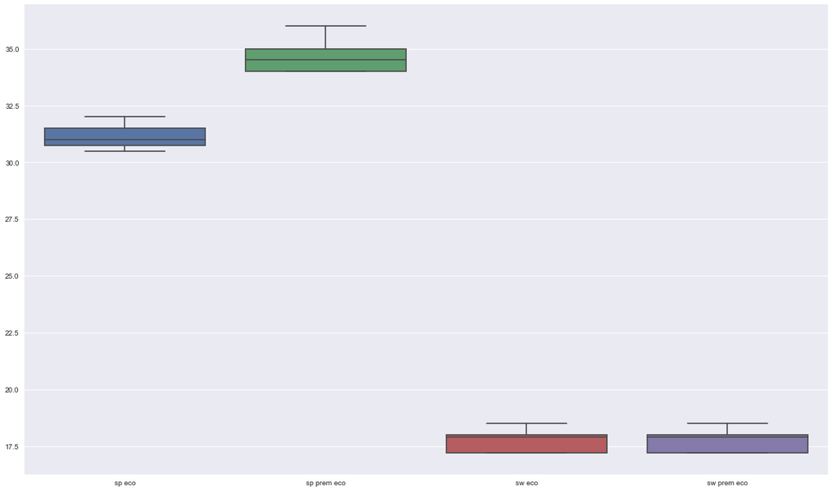

```python
tt=delta.loc[delta['Economy'] == 1]
t=delta.loc[delta['Eco Comfort'] == 1]

df=pd.DataFrame(data={'sw eco': tt['Seat Width (Economy)'] ,
                         'sw prem eco':t['Seat Width (Eco Comfort)'],
                         'sp eco':tt['Seat Pitch (Economy)'],
                         'sp prem eco':t['Seat Pitch (Eco Comfort)']
                         })

fig = plt.figure(figsize=(20,12))
sns.set_context(font_scale=1.5)
sns.boxplot(data=df)
```

according to the boxplots the seat pitch (the distance between two places vertically) of the Eco comfort class is greater than the economy class, it is indeed a remarkable difference. On the other hand, the seat width is almost the same in both classes

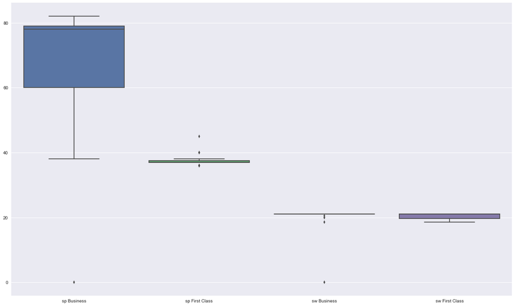

```python
tt=delta.loc[delta['Business'] == 1]
t=delta.loc[delta['First Class'] == 1]

df=pd.DataFrame(data={'sw Business': tt['Seat Width (Business)'] ,
                         'sw First Class':t['Seat Width (First Class)'],
                         'sp Business':tt['Seat Pitch (Business)'],
                         'sp First Class':t['Seat Pitch (First Class)']
                         })



fig = plt.figure(figsize=(20,12))
sns.set_context(font_scale=1.5)
sns.boxplot(data=df)
```

The seat pitch of the business class is greater than the seat pitch in the first class. the seat width of the business class concentrates with the median, it means that almost in all the aircrafts the places of the first class have almost the same seat width. The values of seat width of the first class are not very far it is not a big difference

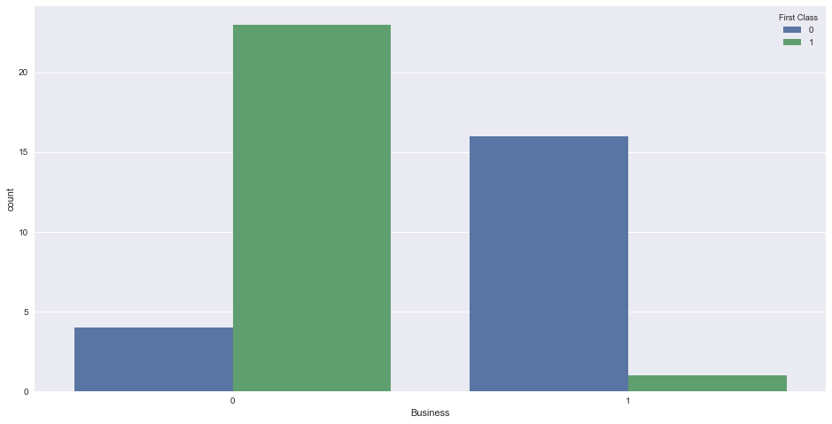

```python
fig = plt.figure(figsize=(16,8))
ax = sns.countplot(x='Business',hue='First Class',data=delta)
```

the absence of the business class in some aircraft generally leads to an increase in the number of First Class seats and the presence of business class seats is generally accompanied by a decrease in first class seats

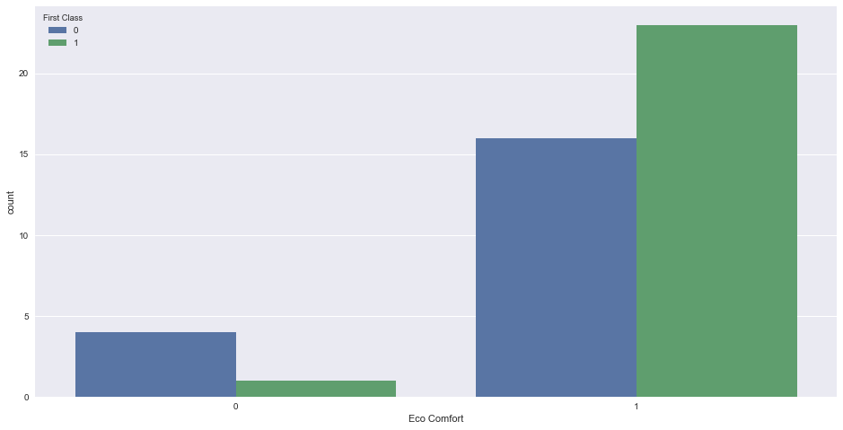

```python
fig = plt.figure(figsize=(16,8))
ax = sns.countplot(x='Eco Comfort',hue='First Class',data=delta)
```

the absence of the Eco Comfort class is accompanied by a drop in the number of seats first and non first class  
on the other hand its presence increases the number of places especially the first class places

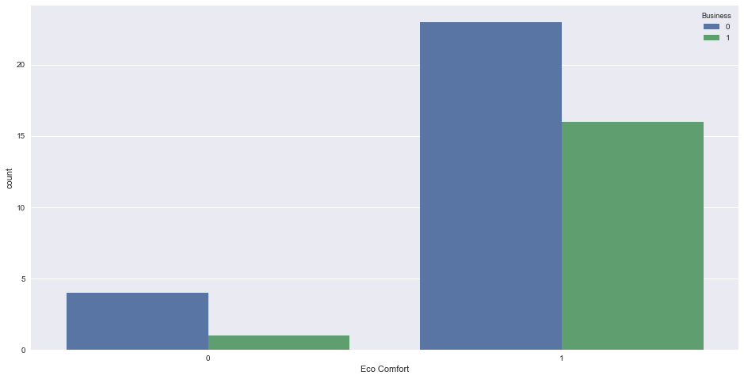

```python
fig = plt.figure(figsize=(16,8))
ax = sns.countplot(x='Eco Comfort',hue='Business',data=delta)
```

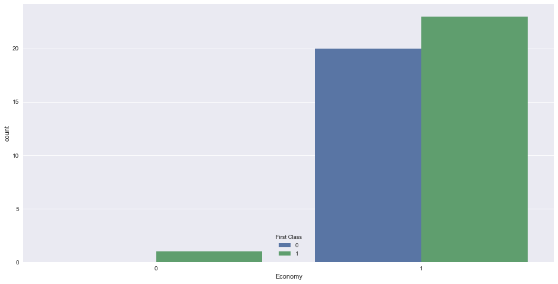

```python
fig = plt.figure(figsize=(16,8))
ax = sns.countplot(x='Economy',hue='First Class',data=delta)
```

the absence of the economy class indicates that the places are limited and necessarily containing places first class but the presence of the economic class can be accompanied by the first class

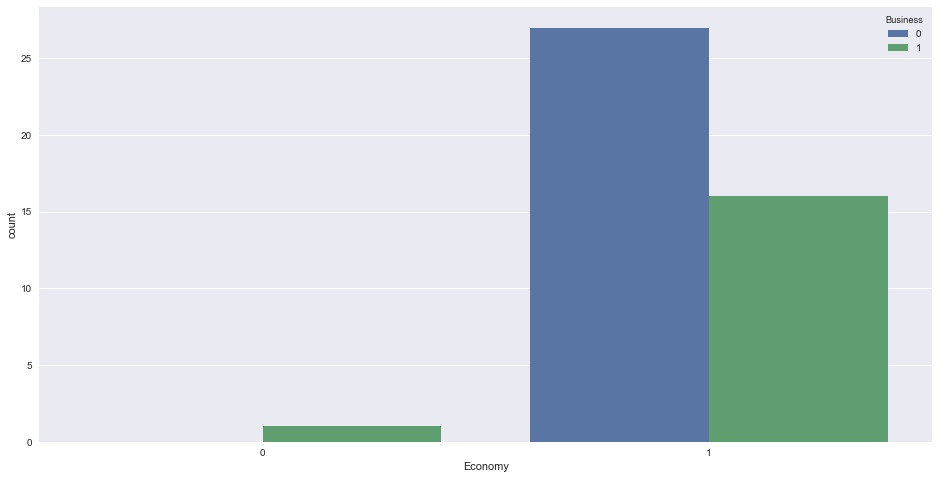

```python
fig = plt.figure(figsize=(16,8))
ax = sns.countplot(x='Economy',hue='Business',data=delta)
```

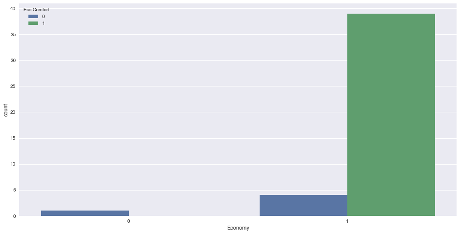

```python
fig = plt.figure(figsize=(16,8))
ax = sns.countplot(x='Economy',hue='Eco Comfort',data=delta)
```

the economy class is usually accompanied by the eco comfort class

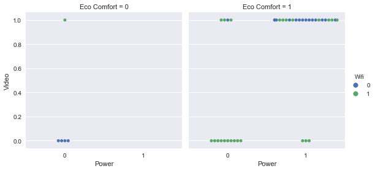

```python
g = sns.factorplot("Power", "Video", "Wifi", col="Eco Comfort", data=delta, kind="swarm")
```

in the eco comfort class if there is no video generally we always find wifi

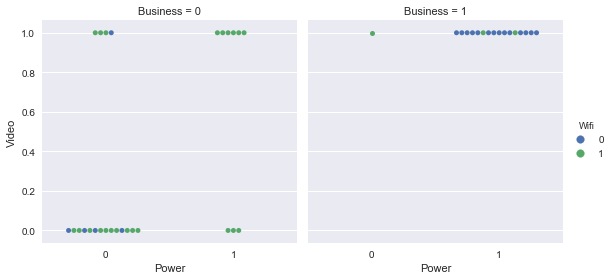

```python
g = sns.factorplot("Power", "Video", "Wifi", col="Business", data=delta, kind="swarm")
```

In the business class generally there is always "power" and "video" the wifi is not necessary

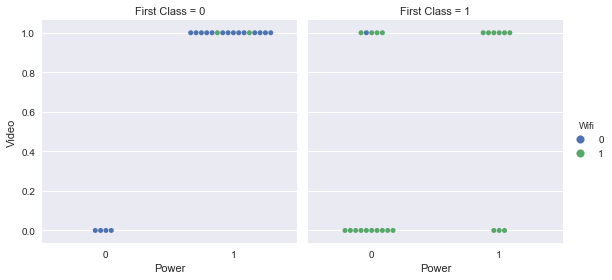

```python
g = sns.factorplot("Power", "Video", "Wifi", col="First Class", data=delta, kind="swarm")
```

in the first class there is always wifi

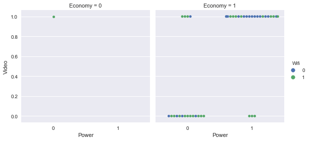

```python
g = sns.factorplot("Power", "Video", "Wifi", col="Economy", data=delta, kind="swarm")
```

the economic class is still existing

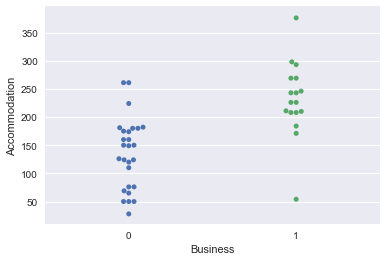

```python
sns.swarmplot(x="Business", y="Accommodation", data=delta)
```

business class planes have more seats

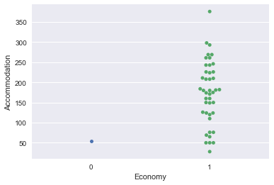

```python
sns.swarmplot(x="Economy", y="Accommodation", data=delta)
```

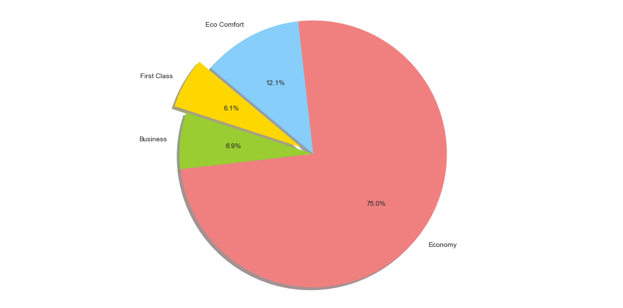

```python
labels = 'First Class', 'Business', 'Economy', 'Eco Comfort'
sizes = [delta['Seats (First Class)'].sum(),delta['Seats (Business)'].sum(),delta['Seats (Economy)'].sum(),delta['Seats (Eco Comfort)'].sum()]
colors = ['gold', 'yellowgreen', 'lightcoral', 'lightskyblue']
explode = (0.1, 0, 0, 0)  # explode 1st slice
fig = plt.figure(figsize=(16,8))

# Plot
plt.pie(sizes, explode=explode, labels=labels, colors=colors,
        autopct='%1.1f%%', shadow=True, startangle=140)

plt.axis('equal')
plt.show()
```

the two types of classes that have a large number of seats are Economy and Eco comfort

```python
Class=[]
c=''
for index, row in delta.iterrows():
        if(row['Economy']==1):
            c+=' Economy'
        if(row['Eco Comfort']==1):
            c+=' EcoComfort'
        if(row['Business']==1):
            c+=' Business'
        if(row['First Class']==1):
            c+=' FirstClass'
        Class.append(c)
        c=''


Class
delta['Class']=Class
delta['Class'].unique()
```

```
array([' Economy EcoComfort FirstClass', ' Business FirstClass',
       ' Economy EcoComfort Business', ' Economy'], dtype=object)
```

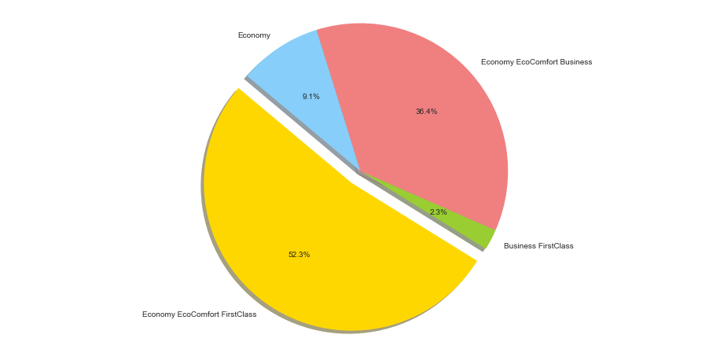

```python
c1=delta.loc[delta['Class'] ==' Economy EcoComfort FirstClass' ]
c2=delta.loc[delta['Class'] ==' Business FirstClass' ]
c3=delta.loc[delta['Class'] ==' Economy EcoComfort Business' ]
c4=delta.loc[delta['Class'] ==' Economy' ]
labels = 'Economy EcoComfort FirstClass', 'Business FirstClass', 'Economy EcoComfort Business', 'Economy'
sizes = [c1['Class'].count(),c2['Class'].count(),c3['Class'].count(),c4['Class'].count()]
colors = ['gold', 'yellowgreen', 'lightcoral', 'lightskyblue']
explode = (0.1, 0, 0, 0)  # explode 1st slice
fig = plt.figure(figsize=(16,8))

# Plot
plt.pie(sizes, explode=explode, labels=labels, colors=colors,
        autopct='%1.1f%%', shadow=True, startangle=140)

plt.axis('equal')
plt.show()
```

the most common combination in terms of class is: Economy, Eco Comfort and first class

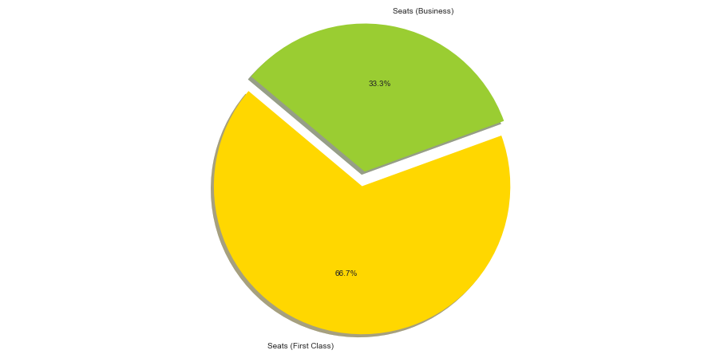

```python
f=c2['Seats (First Class)'].sum()
b=c2['Seats (Business)'].sum()

labels = 'Seats (First Class)', 'Seats (Business)'
sizes = [f,b]
colors = ['gold', 'yellowgreen', 'lightcoral', 'lightskyblue']
explode = (0.1, 0)  # explode 1st slice
fig = plt.figure(figsize=(16,8))

# Plot
plt.pie(sizes, explode=explode, labels=labels, colors=colors,
        autopct='%1.1f%%', shadow=True, startangle=140)

plt.axis('equal')
plt.show()
```

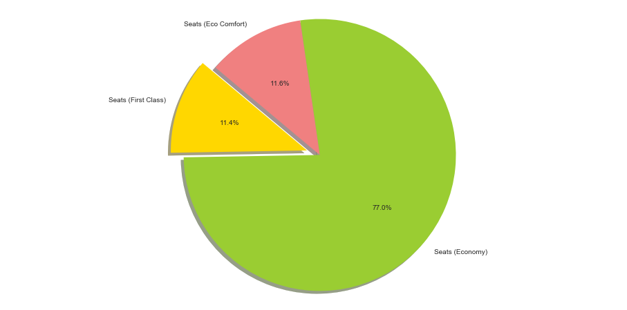

```python
f=c1['Seats (First Class)'].sum()
b=c1['Seats (Economy)'].sum()
com=c1['Seats (Eco Comfort)'].sum()

labels = 'Seats (First Class)', 'Seats (Economy)', 'Seats (Eco Comfort)'
sizes = [f,b,com]
colors = ['gold', 'yellowgreen', 'lightcoral', 'lightskyblue']
explode = (0.1, 0, 0)  # explode 1st slice
fig = plt.figure(figsize=(16,8))

# Plot
plt.pie(sizes, explode=explode, labels=labels, colors=colors,
        autopct='%1.1f%%', shadow=True, startangle=140)

plt.axis('equal')
plt.show()
```

the economy class is the most widespread class it has the largest number of places

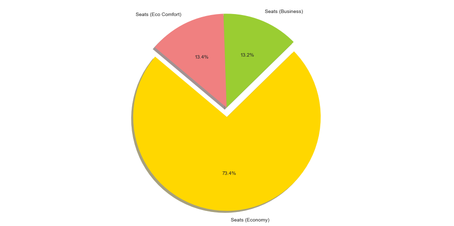

```python
e=c3['Seats (Economy)'].sum()
b=c3['Seats (Business)'].sum()
com=c3['Seats (Eco Comfort)'].sum()


labels = 'Seats (Economy)', 'Seats (Business)','Seats (Eco Comfort)'
sizes = [e,b,com]
colors = ['gold', 'yellowgreen', 'lightcoral', 'lightskyblue']
explode = (0.1, 0,0)  # explode 1st slice
fig = plt.figure(figsize=(16,8))

# Plot
plt.pie(sizes, explode=explode, labels=labels, colors=colors,
        autopct='%1.1f%%', shadow=True, startangle=140)

plt.axis('equal')
plt.show()
```

the economic class remains the most widespread even if it is combined with the business class instead of the first class

```python
a=tunisair.drop(columns=['Name'])
a.head()
```

|  | Reg | AircraftType | config | delivered | Age | Airline |
| --- | --- | --- | --- | --- | --- | --- |
| 0 | TS-IMJ | Airbus A319-100 | Y144 | Aug 1998 | 19.6 Years | tunisair |
| 1 | TS-IMK | Airbus A319-100 | Y144 | Sep 1998 | 19.5 Years | tunisair |
| 2 | TS-IMO | Airbus A319-100 | C16Y90 | Apr 2001 | 16.9 Years | tunisair |
| 3 | TS-IMQ | Airbus A319-100 | C16Y90 | Apr 2007 | 10.8 Years | tunisair |
| 4 | TS-IMC | Airbus A320-200 | CY162 | Nov 1990 | 27.5 Years | tunisair |

```python
result=result[['Reg', 'AircraftType', 'config','delivered',
                                        'Age']]
result.to_csv('C:\\Users\Sedki\Desktop\Etude de la flotte Tunisair\data\All.csv',index=None)
```

```python
fleet=pd.read_csv('C:\\Users\Sedki\Desktop\Etude de la flotte Tunisair\FleetData.csv')
```

```python
fleet.head()
```

|  | Parent Airline | Airline | Aircraft Type | Current | Future | Historic | Total | Orders | Unit Cost | Total Cost (Current) | Average Age |
| --- | --- | --- | --- | --- | --- | --- | --- | --- | --- | --- | --- |
| 0 | Aegean Airlines | Aegean Airlines | Airbus A319 | 1.0 | NaN | 3.0 | 4.0 | NaN | $90 | $90 | 11.6 |
| 1 | Aegean Airlines | Olympic Air | Airbus A319 | NaN | NaN | 8.0 | 8.0 | NaN | $90 | $0 | NaN |
| 2 | Aegean Airlines | Aegean Airlines | Airbus A320 | 38.0 | NaN | 3.0 | 41.0 | NaN | $98 | $3,724 | 7.5 |
| 3 | Aegean Airlines | Olympic Air | Airbus A320 | NaN | NaN | 9.0 | 9.0 | NaN | $98 | $0 | NaN |
| 4 | Aegean Airlines | Aegean Airlines | Airbus A321 | 8.0 | NaN | NaN | 8.0 | NaN | $115 | $919 | 10.3 |

```python
dd=pd.read_csv('C:\\Users\Sedki\Desktop\Etude de la flotte Tunisair\data\All.csv')
```

```python
price = []
prix=''
for e in dd['AircraftType']:
    for index, row in fleet.iterrows():
        if(e in row['Aircraft Type'] or row['Aircraft Type'] in e):
            prix=row['Unit Cost']
    price.append(prix)
```

```python
len(price)
```

```
1781
```

the file contains 1781 entries

```python
len(dd)
```

```
1781
```

Displaying unique prices :

```python
dd['price']=price
dd['price'].unique()
```

```
array(['$90', '$98', '$25', '$115', '$240', '$216', '$74', '$187', '$66',
       '$433', '$295', '$265', '$73', '$312', '$46', '$316', '$75'],
      dtype=object)
```

```python
dd.head(6)
```

|  | Reg | AircraftType | config | delivered | Age | Airline | price |
| --- | --- | --- | --- | --- | --- | --- | --- |
| 0 | HS-PGN | Airbus A319-132 | Y144 | 23. Jan 2009 | 9.1 Years | BangkokAirways | $90 |
| 1 | HS-PGT | Airbus A319-132 | Y144 | 05. Mar 2008 | 10.0 Years | BangkokAirways | $90 |
| 2 | HS-PGX | Airbus A319-132 | Y144 | 10. Mar 2008 | 10.0 Years | BangkokAirways | $90 |
| 3 | HS-PGY | Airbus A319-132 | Y144 | 07. Apr 2008 | 9.9 Years | BangkokAirways | $90 |
| 4 | HS-PGZ | Airbus A319-132 | Y144 | 13. Nov 2008 | 9.3 Years | BangkokAirways | $90 |
| 5 | HS-PPA | Airbus A319-132 | Y144 | 22. May 2009 | 8.8 Years | BangkokAirways | $90 |

Displaying unique Unit cost :

```python
fleet['Unit Cost'].unique()
```

```
array(['$90', '$98', '$115', '$22', '$74', '$14', '$31', '$75', '$240',
       '$312', '$28', '$316', '$187', '$295', '$265', '$45', '$82',
       '$145', '$175', '$16', '$7', nan, '$216', '$73', '$46', '$6',
       '$18', '$20', '$4', '$72', '$32', '$39', '$41', '$30', '$68', '$8',
       '$29', '$66', '$308', '$433', '$49', '$190', '$47', '$37', '$25',
       '$3', '$12', '$96', '$126', '$320', '$11', '$33', '$50', '$56',
       '$2', '$19'], dtype=object)
```

```python
fleet.head()
```

|  | Parent Airline | Airline | Aircraft Type | Current | Future | Historic | Total | Orders | Unit Cost | Total Cost (Current) | Average Age |
| --- | --- | --- | --- | --- | --- | --- | --- | --- | --- | --- | --- |
| 0 | Aegean Airlines | Aegean Airlines | Airbus A319 | 1.0 | NaN | 3.0 | 4.0 | NaN | $90 | $90 | 11.6 |
| 1 | Aegean Airlines | Olympic Air | Airbus A319 | NaN | NaN | 8.0 | 8.0 | NaN | $90 | $0 | NaN |
| 2 | Aegean Airlines | Aegean Airlines | Airbus A320 | 38.0 | NaN | 3.0 | 41.0 | NaN | $98 | $3,724 | 7.5 |
| 3 | Aegean Airlines | Olympic Air | Airbus A320 | NaN | NaN | 9.0 | 9.0 | NaN | $98 | $0 | NaN |
| 4 | Aegean Airlines | Aegean Airlines | Airbus A321 | 8.0 | NaN | NaN | 8.0 | NaN | $115 | $919 | 10.3 |

```python
fleet.dropna(axis=0)
fleet['Parent Airline']
```

[output not shown]

66 rows × 11 columns